# Cluster Analysis of Customers with R

QA

## Problem Definition

#### 1. Research Question

Perform cluster analysis to identify customer groups on a Russian brand, Kira Plastinina to help the sales team understand the customer characteristics.

#### 2. Metrics of success

Identification of customer groups characteristics.

#### 3. Understanding the context

Kira Plastinina is a Russian brand that is sold through a defunct chain of retail stores in Russia, Ukraine, Kazakhstan, Belarus, China, Philippines, and Armenia. The brand’s Sales and Marketing team would like to understand their customer’s behavior from data that they have collected over the past year. More specifically, they would like to learn the characteristics of customer groups.

#### 4. Recording the experimental design

1. Data Sourcing
2. Check the Data
3. Perform Data Cleaning
4. Perform Exploratory Data Analysis
5. Implement the Solution
6. Challenge the Solution
7. Follow up Questions

## 1. Data Sourcing

[http://bit.ly/EcommerceCustomersDataset]

## Data Loading and Inspection

```r
# Load libraries
library(readr)
library(tidyverse)
library(psych)
```

```r
library(corrplot)
library(BBmisc)
library(caret)
library(cluster)
library(factoextra)
library(NbClust)
```

```r
df <- read_csv("C:\\Users\\Lenovo\\Downloads\\online_shoppers_intention.csv")
# Preview data
head(df)
```

```
## # A tibble: 6 x 18
##   Administrative Administrative_D~ Informational Informational_D~ ProductRelated
##            <dbl>             <dbl>         <dbl>            <dbl>          <dbl>
## 1              0                 0             0                0              1
## 2              0                 0             0                0              2
## 3              0                -1             0               -1              1
## 4              0                 0             0                0              2
## 5              0                 0             0                0             10
## 6              0                 0             0                0             19
## # ... with 13 more variables: ProductRelated_Duration <dbl>, BounceRates <dbl>,
## #   ExitRates <dbl>, PageValues <dbl>, SpecialDay <dbl>, Month <chr>,
## #   OperatingSystems <dbl>, Browser <dbl>, Region <dbl>, TrafficType <dbl>,
## #   VisitorType <chr>, Weekend <lgl>, Revenue <lgl>
```

## 2. Check the Data

```r
# Shape of data
dim(df);
```

```
## [1] 12330    18
```

```r
# Column datatypes
str(df);
```

```
## spec_tbl_df [12,330 x 18] (S3: spec_tbl_df/tbl_df/tbl/data.frame)
##  $ Administrative         : num [1:12330] 0 0 0 0 0 0 0 1 0 0 ...
##  $ Administrative_Duration: num [1:12330] 0 0 -1 0 0 0 -1 -1 0 0 ...
##  $ Informational          : num [1:12330] 0 0 0 0 0 0 0 0 0 0 ...
##  $ Informational_Duration : num [1:12330] 0 0 -1 0 0 0 -1 -1 0 0 ...
##  $ ProductRelated         : num [1:12330] 1 2 1 2 10 19 1 1 2 3 ...
##  $ ProductRelated_Duration: num [1:12330] 0 64 -1 2.67 627.5 ...
##  $ BounceRates            : num [1:12330] 0.2 0 0.2 0.05 0.02 ...
##  $ ExitRates              : num [1:12330] 0.2 0.1 0.2 0.14 0.05 ...
##  $ PageValues             : num [1:12330] 0 0 0 0 0 0 0 0 0 0 ...
##  $ SpecialDay             : num [1:12330] 0 0 0 0 0 0 0.4 0 0.8 0.4 ...
##  $ Month                  : chr [1:12330] "Feb" "Feb" "Feb" "Feb" ...
##  $ OperatingSystems       : num [1:12330] 1 2 4 3 3 2 2 1 2 2 ...
##  $ Browser                : num [1:12330] 1 2 1 2 3 2 4 2 2 4 ...
##  $ Region                 : num [1:12330] 1 1 9 2 1 1 3 1 2 1 ...
##  $ TrafficType            : num [1:12330] 1 2 3 4 4 3 3 5 3 2 ...
##  $ VisitorType            : chr [1:12330] "Returning_Visitor" "Returning_Visitor" "Returning_Visitor" "Returning_Visitor" ...
##  $ Weekend                : logi [1:12330] FALSE FALSE FALSE FALSE TRUE FALSE ...
##  $ Revenue                : logi [1:12330] FALSE FALSE FALSE FALSE FALSE FALSE ...
##  - attr(*, "spec")=
##   .. cols(
##   ..   Administrative = col_double(),
##   ..   Administrative_Duration = col_double(),
##   ..   Informational = col_double(),
##   ..   Informational_Duration = col_double(),
##   ..   ProductRelated = col_double(),
##   ..   ProductRelated_Duration = col_double(),
##   ..   BounceRates = col_double(),
##   ..   ExitRates = col_double(),
##   ..   PageValues = col_double(),
##   ..   SpecialDay = col_double(),
##   ..   Month = col_character(),
##   ..   OperatingSystems = col_double(),
##   ..   Browser = col_double(),
##   ..   Region = col_double(),
##   ..   TrafficType = col_double(),
##   ..   VisitorType = col_character(),
##   ..   Weekend = col_logical(),
##   ..   Revenue = col_logical()
##   .. )
```

```r
# Data Summary
summary(df)
```

```
##  Administrative   Administrative_Duration Informational
##  Min.   : 0.000   Min.   :  -1.00         Min.   : 0.000
##  1st Qu.: 0.000   1st Qu.:   0.00         1st Qu.: 0.000
##  Median : 1.000   Median :   8.00         Median : 0.000
##  Mean   : 2.318   Mean   :  80.91         Mean   : 0.504
##  3rd Qu.: 4.000   3rd Qu.:  93.50         3rd Qu.: 0.000
##  Max.   :27.000   Max.   :3398.75         Max.   :24.000
##  NA's   :14       NA's   :14              NA's   :14
##  Informational_Duration ProductRelated   ProductRelated_Duration
##  Min.   :  -1.00        Min.   :  0.00   Min.   :   -1.0
##  1st Qu.:   0.00        1st Qu.:  7.00   1st Qu.:  185.0
##  Median :   0.00        Median : 18.00   Median :  599.8
##  Mean   :  34.51        Mean   : 31.76   Mean   : 1196.0
##  3rd Qu.:   0.00        3rd Qu.: 38.00   3rd Qu.: 1466.5
##  Max.   :2549.38        Max.   :705.00   Max.   :63973.5
##  NA's   :14             NA's   :14       NA's   :14
##   BounceRates         ExitRates         PageValues        SpecialDay
##  Min.   :0.000000   Min.   :0.00000   Min.   :  0.000   Min.   :0.00000
##  1st Qu.:0.000000   1st Qu.:0.01429   1st Qu.:  0.000   1st Qu.:0.00000
##  Median :0.003119   Median :0.02512   Median :  0.000   Median :0.00000
##  Mean   :0.022152   Mean   :0.04300   Mean   :  5.889   Mean   :0.06143
##  3rd Qu.:0.016684   3rd Qu.:0.05000   3rd Qu.:  0.000   3rd Qu.:0.00000
##  Max.   :0.200000   Max.   :0.20000   Max.   :361.764   Max.   :1.00000
##  NA's   :14         NA's   :14
##     Month           OperatingSystems    Browser           Region
##  Length:12330       Min.   :1.000    Min.   : 1.000   Min.   :1.000
##  Class :character   1st Qu.:2.000    1st Qu.: 2.000   1st Qu.:1.000
##  Mode  :character   Median :2.000    Median : 2.000   Median :3.000
##                     Mean   :2.124    Mean   : 2.357   Mean   :3.147
##                     3rd Qu.:3.000    3rd Qu.: 2.000   3rd Qu.:4.000
##                     Max.   :8.000    Max.   :13.000   Max.   :9.000
##
##   TrafficType    VisitorType         Weekend         Revenue
##  Min.   : 1.00   Length:12330       Mode :logical   Mode :logical
##  1st Qu.: 2.00   Class :character   FALSE:9462      FALSE:10422
##  Median : 2.00   Mode  :character   TRUE :2868      TRUE :1908
##  Mean   : 4.07
##  3rd Qu.: 4.00
##  Max.   :20.00
##
```

The following columns contain some NA’s: - Administrative - Administrative_Duration - Informational - Informational_Duration - ProductRelated - ProductRelated_Duration - BounceRates - ExitRates - PageValues

**Worth noting:** There are durations that have **-1** as values that may need to be dropped.

## 3. Data Cleaning

```r
# Checking for duplicated data
anyDuplicated(df)
```

```
## [1] 159
```

```r
# Dropping the Duplicated rows
df <- df[!duplicated(df),]
anyDuplicated((df))
```

```
## [1] 0
```

BOOM! Duplicates gone

```r
# Get number of rows with null values
df[!complete.cases(df),]
```

```
## # A tibble: 12 x 18
##    Administrative Administrative_~ Informational Informational_D~ ProductRelated
##             <dbl>            <dbl>         <dbl>            <dbl>          <dbl>
##  1             NA               NA            NA               NA             NA
##  2             NA               NA            NA               NA             NA
##  3             NA               NA            NA               NA             NA
##  4             NA               NA            NA               NA             NA
##  5             NA               NA            NA               NA             NA
##  6             NA               NA            NA               NA             NA
##  7             NA               NA            NA               NA             NA
##  8             NA               NA            NA               NA             NA
##  9             NA               NA            NA               NA             NA
## 10             NA               NA            NA               NA             NA
## 11             NA               NA            NA               NA             NA
## 12             NA               NA            NA               NA             NA
## # ... with 13 more variables: ProductRelated_Duration <dbl>, BounceRates <dbl>,
## #   ExitRates <dbl>, PageValues <dbl>, SpecialDay <dbl>, Month <chr>,
## #   OperatingSystems <dbl>, Browser <dbl>, Region <dbl>, TrafficType <dbl>,
## #   VisitorType <chr>, Weekend <lgl>, Revenue <lgl>
```

It is the same rows with missing values!!! *Drop them!!!*

```r
# Drop the NA rows
df <- df[complete.cases(df),]
```

```r
# Investigating the -1 values in the duration columns
anomalies <- df %>% select(c(Administrative_Duration, Administrative, Informational_Duration, Informational, ProductRelated_Duration, ProductRelated)) %>% filter(Administrative_Duration == -1 | Informational_Duration == -1 | ProductRelated_Duration == -1)
anomalies
```

```
## # A tibble: 33 x 6
##    Administrative_Duration Administrative Informational_Duration Informational
##                      <dbl>          <dbl>                  <dbl>         <dbl>
##  1                      -1              0                     -1             0
##  2                      -1              0                     -1             0
##  3                      -1              1                     -1             0
##  4                      -1              0                     -1             0
##  5                      -1              0                     -1             0
##  6                      -1              0                     -1             0
##  7                      -1              0                     -1             0
##  8                      -1              0                     -1             0
##  9                      -1              0                     -1             0
## 10                      -1              0                     -1             0
## # ... with 23 more rows, and 2 more variables: ProductRelated_Duration <dbl>,
## #   ProductRelated <dbl>
```

> A total of 33 rows have the anomalies.

```r
# Dropping the anomalies anomalous data
df <- df %>% filter(Administrative_Duration != -1, Informational_Duration != -1, ProductRelated_Duration != 1)
```

```r
# describe each column
describe(df[, c(1:9)])
```

```
##                         vars     n    mean      sd median trimmed    mad min
## Administrative             1 12164    2.35    3.33   1.00    1.66   1.48   0
## Administrative_Duration    2 12164   81.92  177.73  10.00   43.06  14.83   0
## Informational              3 12164    0.51    1.28   0.00    0.18   0.00   0
## Informational_Duration     4 12164   34.94  141.65   0.00    3.76   0.00   0
## ProductRelated             5 12164   32.15   44.63  18.00   23.14  19.27   0
## ProductRelated_Duration    6 12164 1210.99 1921.59 613.24  835.59 747.59   0
## BounceRates                7 12164    0.02    0.04   0.00    0.01   0.00   0
## ExitRates                  8 12164    0.04    0.05   0.03    0.03   0.02   0
## PageValues                 9 12164    5.97   18.68   0.00    1.34   0.00   0
##                              max    range skew kurtosis    se
## Administrative             27.00    27.00 1.94     4.62  0.03
## Administrative_Duration  3398.75  3398.75 5.58    49.97  1.61
## Informational              24.00    24.00 4.01    26.56  0.01
## Informational_Duration   2549.38  2549.38 7.53    75.23  1.28
## ProductRelated            705.00   705.00 4.33    31.01  0.40
## ProductRelated_Duration 63973.52 63973.52 7.25   136.43 17.42
## BounceRates                 0.20     0.20 3.21     9.71  0.00
## ExitRates                   0.20     0.20 2.26     4.79  0.00
## PageValues                361.76   361.76 6.34    64.75  0.17
```

**Observations** - All the numerical columns data values are positively skewed - All the numerical columns data are leptokurtic

```r
# Outlier function
outlier_detector <- function(x){
  out <- boxplot.stats(x)$out
  return((length(out)/  length(x)*100))
}
```

```r
# Get outlier count per column
sapply(df[,c(1:9)], outlier_detector)
```

```
##          Administrative Administrative_Duration           Informational
##                3.321276                9.363696               21.621177
##  Informational_Duration          ProductRelated ProductRelated_Duration
##               19.763236                8.278527                7.809931
##             BounceRates               ExitRates              PageValues
##               11.649129               10.637948               22.443275
```

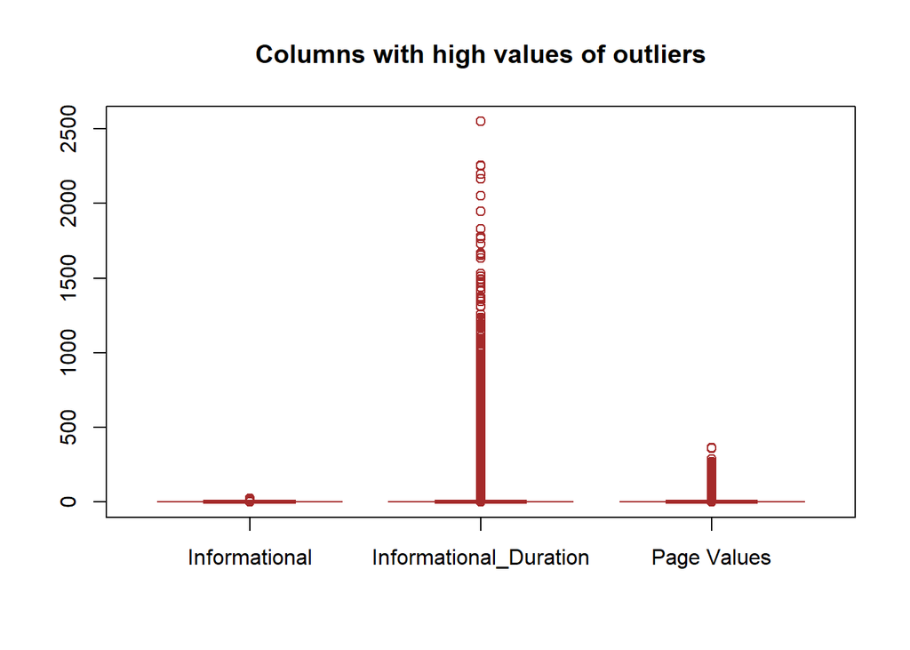

```r
# Plot boxplots of columns with high % of outliers
boxplot(df$Informational, df$Informational_Duration, df$PageValues,
main = "Columns with high values of outliers",
names = c("Informational", "Informational_Duration", "Page Values"),
col = c("orange","red"),
border = "brown",
notch = TRUE)
```

**Observations** - All outliers are contained above the third quantile. - The outliers may be true values as sometimes durations spent on a page may be long

## 4. Exploratory Data Analysis

```r
# Frequency distribution of categorical columns
sapply(df[, c(10:18)], table)
```

```
## $SpecialDay
##
##     0   0.2   0.4   0.6   0.8     1
## 10918   178   242   348   324   154
##
## $Month
##
##  Aug  Dec  Feb  Jul June  Mar  May  Nov  Oct  Sep
##  433 1706  169  431  285 1842 3321 2980  549  448
##
## $OperatingSystems
##
##    1    2    3    4    5    6    7    8
## 2539 6519 2523  476    6   19    7   75
##
## $Browser
##
##    1    2    3    4    5    6    7    8    9   10   11   12   13
## 2418 7859  104  727  464  174   49  134    1  162    6   10   56
##
## $Region
##
##    1    2    3    4    5    6    7    8    9
## 4701 1122 2374 1164  315  800  755  431  502
##
## $TrafficType
##
##    1    2    3    4    5    6    7    8    9   10   11   12   13   14   15   16
## 2373 3905 2002 1064  259  440   40  343   41  450  247    1  727   13   36    3
##   17   18   19   20
##    1   10   17  192
##
## $VisitorType
##
##       New_Visitor             Other Returning_Visitor
##              1693                81             10390
##
## $Weekend
##
## FALSE  TRUE
##  9311  2853
##
## $Revenue
##
## FALSE  TRUE
## 10256  1908
```

*Summary of frequency table* - SpecialDay 0 has the highest count - May and November receives the highest traffic - Operating system 2 is the most used to visit the site - Browser 2 is most used by visitors - Most visitors to the site are from Region 1 - Most of the traffic to the website is of type 2 and 1 - Most of the visitors to the site are mostly returning visitors - Most visitors visit the site during the weekday - Most visits to the site do not earn revenue

```r
# Number of visits to product related pages per month
product_stats <- df %>% select(ProductRelated, ProductRelated_Duration, Month)%>%group_by(Month)%>% summarise_all(mean)
product_stats[order(product_stats$ProductRelated, decreasing = TRUE),]
```

```
## # A tibble: 10 x 3
##    Month ProductRelated ProductRelated_Duration
##    <chr>          <dbl>                   <dbl>
##  1 Nov             46.3                   1769.
##  2 Aug             38.3                   1273.
##  3 Jul             36.5                   1220.
##  4 June            36.4                   1226.
##  5 Oct             33.6                   1117.
##  6 Sep             33.1                   1253.
##  7 Dec             28.3                   1125.
##  8 May             26.8                    995.
##  9 Mar             20.5                    841.
## 10 Feb             12.1                    513.
```

November had the highest number of visits to product related pages with the highest duration

```r
# Distribution of revenue generating visits among visitors
df %>% select(VisitorType, Revenue)%>% group_by(VisitorType, Revenue)%>% summarise(visits = n())%>% filter(Revenue==TRUE)
```

```
## # A tibble: 3 x 3
## # Groups:   VisitorType [3]
##   VisitorType       Revenue visits
##   <chr>             <lgl>    <int>
## 1 New_Visitor       TRUE       422
## 2 Other             TRUE        16
## 3 Returning_Visitor TRUE      1470
```

> Returning visitors have the generate the most revenue.

```r
# Distribution of revenue generating visits among regions
df %>% select(Region, Revenue)%>% group_by(Region, Revenue)%>% summarise(visits = n())%>% filter(Revenue==TRUE)
```

```
## # A tibble: 9 x 3
## # Groups:   Region [9]
##   Region Revenue visits
##    <dbl> <lgl>    <int>
## 1      1 TRUE       771
## 2      2 TRUE       188
## 3      3 TRUE       349
## 4      4 TRUE       175
## 5      5 TRUE        52
## 6      6 TRUE       112
## 7      7 TRUE       119
## 8      8 TRUE        56
## 9      9 TRUE        86
```

Visitors from Region 1 make most revenue generating visits

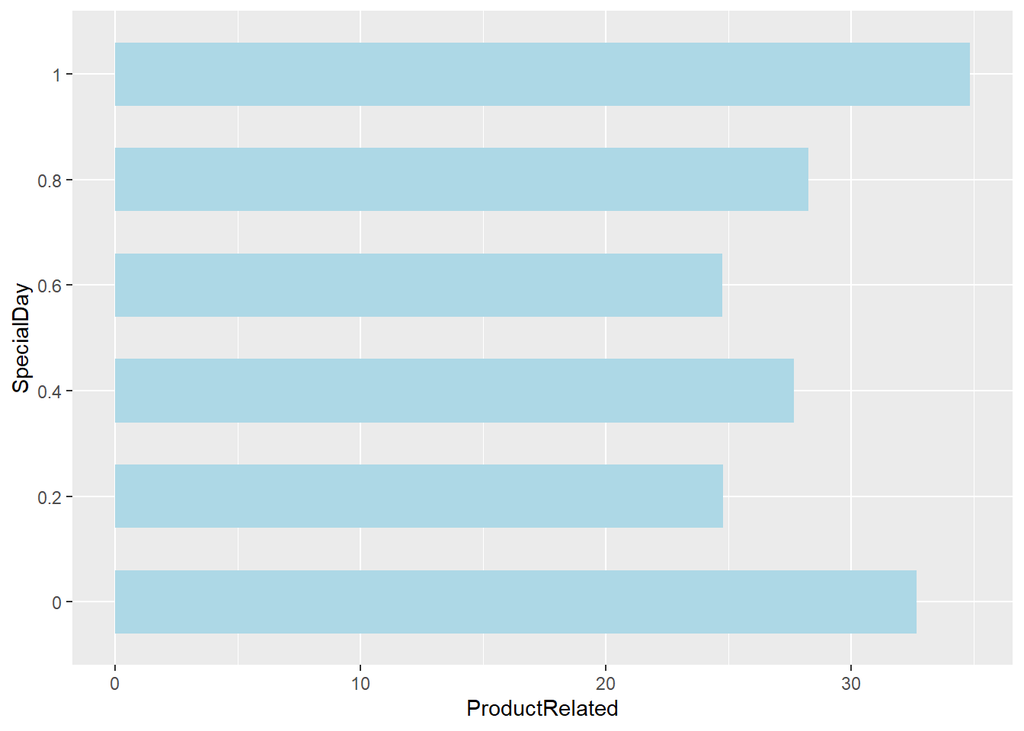

```r
# Get page values and visits to product pages based on proximity to a special day
special_product <- df %>% select(SpecialDay, PageValues, ProductRelated, ProductRelated_Duration)%>% group_by(SpecialDay)%>% summarise_all(mean)
ggplot(special_product, aes(x = factor(SpecialDay), y=ProductRelated))+
  geom_bar(fill = 'lightblue', stat = "identity", width = 0.6) +
  labs(x = 'SpecialDay')+
  coord_flip()
```

> On special days customers visit the highest number of product related pages, with the highest mean number of pages visited.

```r
# Distribution of revenue generating visits based on proximity to special days
revenue_special <- df %>% select(SpecialDay, Revenue)%>% group_by(SpecialDay, Revenue)%>% summarise(count = n())%>% mutate(freq = count / sum(count)) %>% filter(Revenue==TRUE)%>% mutate(freq = round((freq * 100), 1))
```

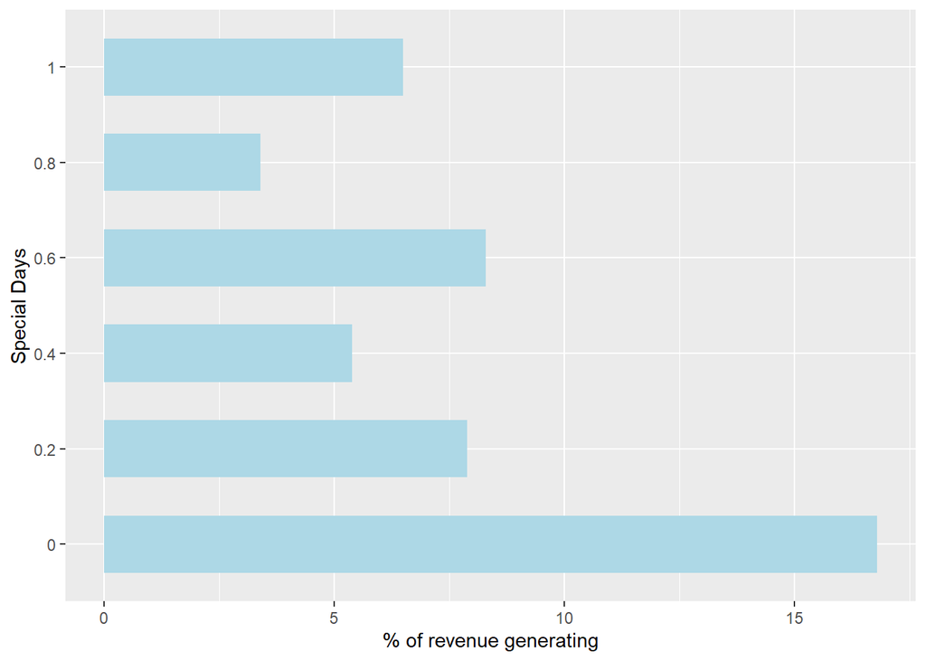

```r
revenue_special <- revenue_special[order(revenue_special$freq, decreasing = TRUE),]
ggplot(revenue_special, aes(x = factor(SpecialDay), y=freq))+
  geom_bar(fill = 'lightblue', stat = "identity", width = 0.6) +
  labs(y = '% of revenue generating', x = 'Special Days' )+
  coord_flip()
```

> Ordinary days have the highest percentage of visits that are income generating

```r
# Get bounce rates and exit rates among visitor groups
visitor_stats <- df %>% select(VisitorType, ExitRates, BounceRates)%>% group_by(VisitorType)%>%summarise_all(mean)
visitor_stats
```

```
## # A tibble: 3 x 3
##   VisitorType       ExitRates BounceRates
##   <chr>                 <dbl>       <dbl>
## 1 New_Visitor          0.0206     0.00515
## 2 Other                0.0566     0.0306
## 3 Returning_Visitor    0.0443     0.0223
```

**Observations** - Other visitors have the highest exit rates and bounce rates - New_Visitor have the lowest exit and bounce rates

```r
# Page views and durations based on visitor type
df %>% select(VisitorType, Administrative:ProductRelated_Duration)%>% group_by(VisitorType)%>%summarise_all(mean)
```

```
## # A tibble: 3 x 7
##   VisitorType   Administrative Administrative_D~ Informational Informational_Du~
##   <chr>                  <dbl>             <dbl>         <dbl>             <dbl>
## 1 New_Visitor             2.55              92.0         0.334              19.2
## 2 Other                   1.54              65.8         0.185              12.3
## 3 Returning_Vi~           2.32              80.4         0.542              37.7
## # ... with 2 more variables: ProductRelated <dbl>,
## #   ProductRelated_Duration <dbl>
```

**Observations** - On average that New_Vistor have the longest Administrative_Duration followed by Returning_Visitor and lastly Other - Returning_Visitor have on average the longest Informational_Duration and ProductRelated_Duration

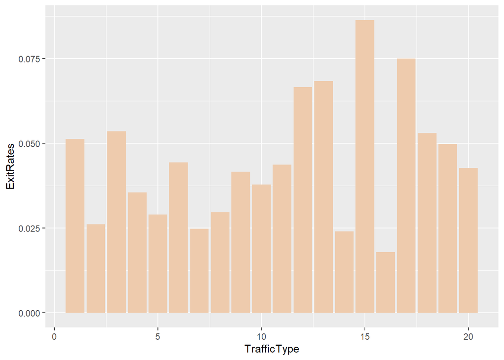

```r
traffic_stats <- df %>% select(TrafficType, ExitRates, BounceRates)%>% group_by(TrafficType)%>% summarise_all(mean)
par(mfrow = c(1,2))
ggplot(traffic_stats, aes(x=TrafficType, y = ExitRates))+
  geom_bar(stat = "identity", fill="peachpuff2")
```

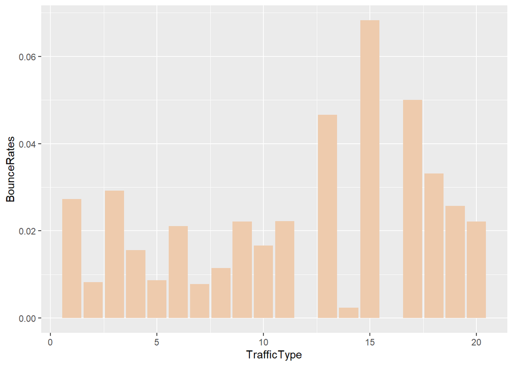

```r
ggplot(traffic_stats, aes(x=TrafficType, y = BounceRates))+
  geom_bar(stat = "identity", fill="peachpuff2")
```

> Traffic of type 15 have the highest bounce rates and average rates on average

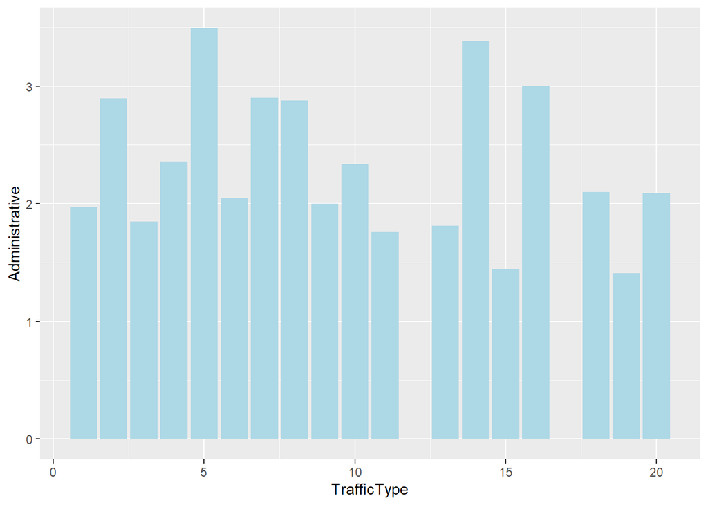

```r
traffic_page_stats <- df %>% select(TrafficType, Administrative:ProductRelated_Duration)%>% group_by(TrafficType)%>% summarise_all(mean)
par(mfrow = c(1,3))
ggplot(traffic_page_stats, aes(x=TrafficType, y = Administrative))+
  geom_bar(stat = "identity", fill="lightblue")
```

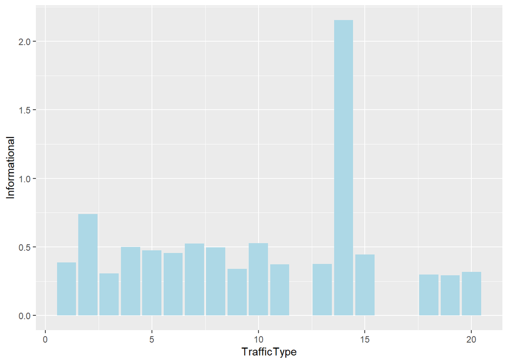

```r
ggplot(traffic_page_stats, aes(x=TrafficType, y = Informational))+
  geom_bar(stat = "identity", fill="lightblue")
```

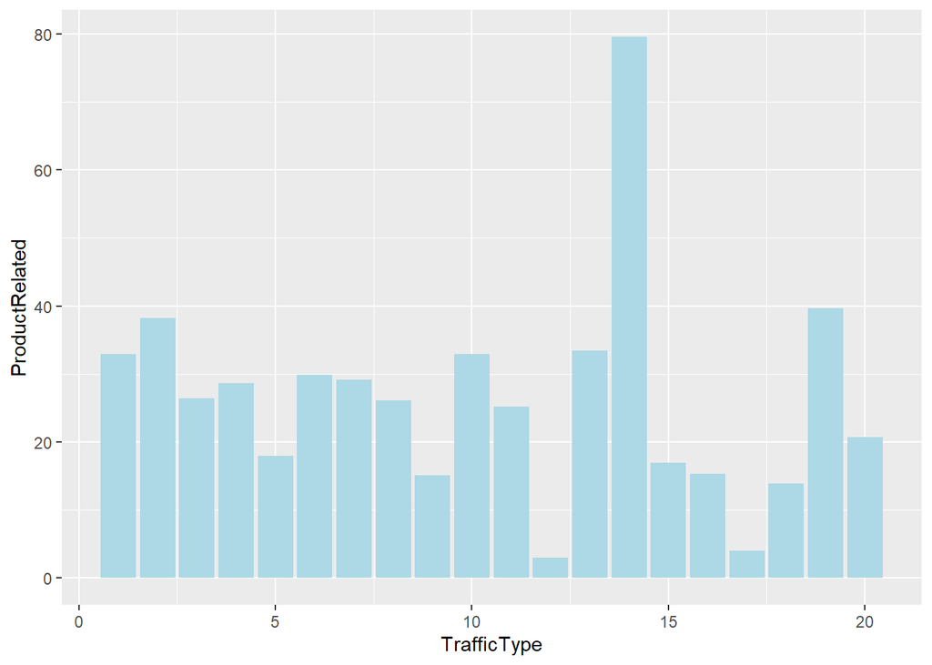

```r
ggplot(traffic_page_stats, aes(x=TrafficType, y = ProductRelated))+
  geom_bar(stat = "identity", fill="lightblue")
```

**Observations** - Traffic 5 on average experiences the highest number of administrative visits - Traffic 14 on average experiences the highest number of informational visits - Traffic 14 on average experiences the highest number of ProductRelated visits

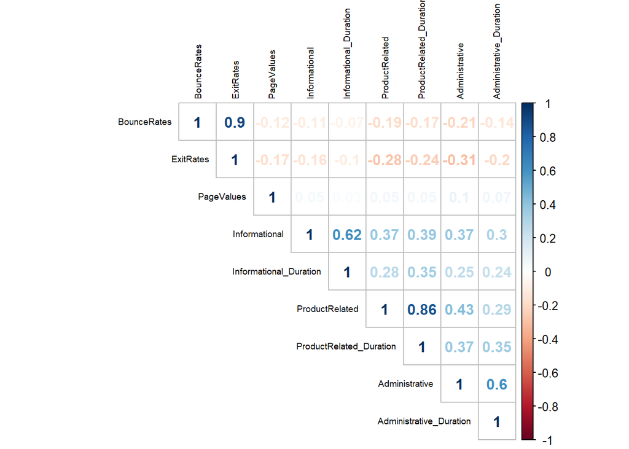

```r
# Correlational plot
corrplot(corr = cor(df[, c(1:9)]), method = "number", type = "upper", order = "hclust", tl.col = "black", tl.cex = 0.6)
```

## 5. Solution Implementation

### K-Means Clustering

```r
# One hot encode categorical features
new_shoppers <- df[, 1:17]
# new_shoppers[, 10:16] <- as.character(new_shoppers[, 10:16])
dmy <- dummyVars("~ SpecialDay + Month + OperatingSystems + Browser + Region + TrafficType + VisitorType", data= new_shoppers)
ohe <- data.frame(predict(dmy, newdata = new_shoppers))
model_data <- cbind(new_shoppers[ , 1:9], ohe)
model_data$Weekend <- as.numeric(df$Weekend)
head(model_data)
```

```
##   Administrative Administrative_Duration Informational Informational_Duration
## 1              0                       0             0                      0
## 2              0                       0             0                      0
## 3              0                       0             0                      0
## 4              0                       0             0                      0
## 5              0                       0             0                      0
## 6              0                       0             0                      0
##   ProductRelated ProductRelated_Duration BounceRates ExitRates PageValues
## 1              1                0.000000  0.20000000 0.2000000          0
## 2              2               64.000000  0.00000000 0.1000000          0
## 3              2                2.666667  0.05000000 0.1400000          0
## 4             10              627.500000  0.02000000 0.0500000          0
## 5             19              154.216667  0.01578947 0.0245614          0
## 6              2               37.000000  0.00000000 0.1000000          0
##   SpecialDay MonthAug MonthDec MonthFeb MonthJul MonthJune MonthMar MonthMay
```

[output cut: 20 more lines]

```r
colnames(df)
```

```
##  [1] "Administrative"          "Administrative_Duration"
##  [3] "Informational"           "Informational_Duration"
##  [5] "ProductRelated"          "ProductRelated_Duration"
##  [7] "BounceRates"             "ExitRates"
##  [9] "PageValues"              "SpecialDay"
## [11] "Month"                   "OperatingSystems"
## [13] "Browser"                 "Region"
## [15] "TrafficType"             "VisitorType"
## [17] "Weekend"                 "Revenue"
```

```r
# Normalizing the continuous features
model_data[, 1:9] <- normalize(model_data[, 1:9], method = "range")
```

```r
# Performing  k-mean clustering with 5 clusters
customer_groups <- kmeans(model_data, centers = 5, nstart = 25)
str(customer_groups)
```

```
## List of 9
##  $ cluster     : Named int [1:12164] 5 5 5 5 5 5 1 5 5 5 ...
##   ..- attr(*, "names")= chr [1:12164] "1" "2" "3" "4" ...
##  $ centers     : num [1:5, 1:28] 0.0781 0.0747 0.0793 0.0871 0.0911 ...
##   ..- attr(*, "dimnames")=List of 2
##   .. ..$ : chr [1:5] "1" "2" "3" "4" ...
##   .. ..$ : chr [1:28] "Administrative" "Administrative_Duration" "Informational" "Informational_Duration" ...
##  $ totss       : num 329285
##  $ withinss    : num [1:5] 13026 9369 23894 15834 34071
##  $ tot.withinss: num 96194
##  $ betweenss   : num 233091
##  $ size        : int [1:5] 1250 222 1855 2253 6584
##  $ iter        : int 4
##  $ ifault      : int 0
##  - attr(*, "class")= chr "kmeans"
```

```r
# Cluster sizes
customer_groups$size
```

```
## [1] 1250  222 1855 2253 6584
```

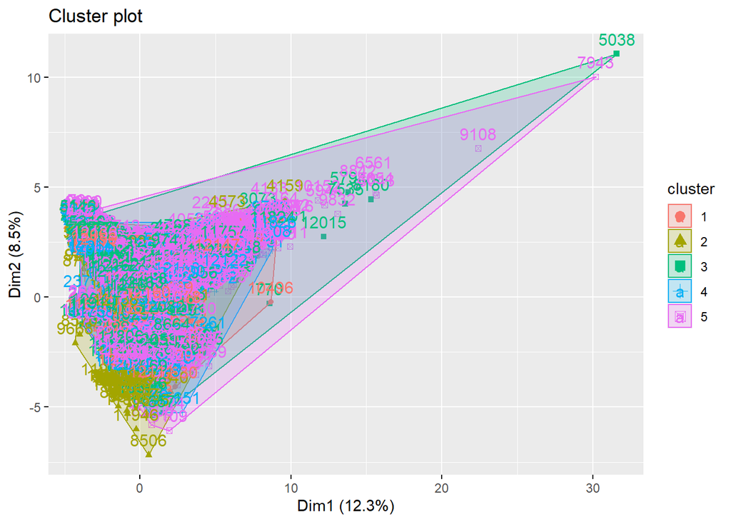

```r
# Visualizing the  clusters
fviz_cluster(customer_groups, data = model_data)
```

```r
# 7 clusters
customer_groups <- kmeans(model_data, centers = 7, nstart = 25)
customer_groups$size
```

```
## [1] 4271 1480  888  222 2900  428 1975
```

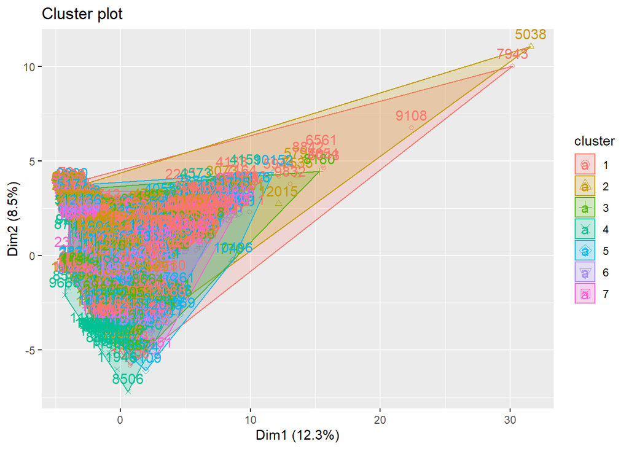

```r
fviz_cluster(customer_groups, data = model_data)
```

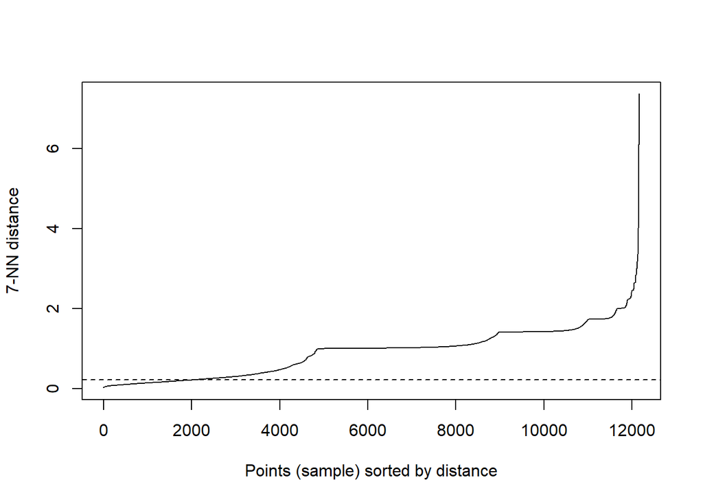

```r
# Determining the optimal value for epislon
dbscan::kNNdistplot(model_data, k =  7)
abline(h = 0.23, lty = 2)
```

```r
db_groups <- dbscan::dbscan(model_data, eps = 0.23, minPts = 7)
db_groups
```

```
## DBSCAN clustering for 12164 objects.
## Parameters: eps = 0.23, minPts = 7
## The clustering contains 206 cluster(s) and 8886 noise points.
##
##    0    1    2    3    4    5    6    7    8    9   10   11   12   13   14   15
## 8886    9   29   83   15   43   19   57    9    9   24   25    7    8    7    7
##   16   17   18   19   20   21   22   23   24   25   26   27   28   29   30   31
##   17   14    8   14    9   16   14   25   26   16   11    9    8    7   11   11
##   32   33   34   35   36   37   38   39   40   41   42   43   44   45   46   47
##    8    8   11    7   12   21    7    9    8    7    7   15   10   19   16   29
##   48   49   50   51   52   53   54   55   56   57   58   59   60   61   62   63
##   20   73   13    9    7    7    7   32   27   15   12    9   73   21    8   11
##   64   65   66   67   68   69   70   71   72   73   74   75   76   77   78   79
##    9   14   33   13    9   13    8   11   10    9   13   17   10   10    8    8
##   80   81   82   83   84   85   86   87   88   89   90   91   92   93   94   95
```

[output cut: 17 more lines]

[figure not shown]

```r
fviz_cluster(db_groups, model_data, geom="point")
```

### Cluster Analysis

```r
df <-  df %>% mutate(group = customer_groups$cluster)
head(df)
```

```
## # A tibble: 6 x 19
##   Administrative Administrative_D~ Informational Informational_D~ ProductRelated
##            <dbl>             <dbl>         <dbl>            <dbl>          <dbl>
## 1              0                 0             0                0              1
## 2              0                 0             0                0              2
## 3              0                 0             0                0              2
## 4              0                 0             0                0             10
## 5              0                 0             0                0             19
## 6              0                 0             0                0              2
## # ... with 14 more variables: ProductRelated_Duration <dbl>, BounceRates <dbl>,
## #   ExitRates <dbl>, PageValues <dbl>, SpecialDay <dbl>, Month <chr>,
## #   OperatingSystems <dbl>, Browser <dbl>, Region <dbl>, TrafficType <dbl>,
## #   VisitorType <chr>, Weekend <lgl>, Revenue <lgl>, group <int>
```

```r
# Summary Statistics
summary_stats <- df %>% group_by(group)%>% select(Administrative:PageValues, group)%>% summarise_all(mean)
summary_stats
```

```
## # A tibble: 7 x 10
##   group Administrative Administrative_Durati~ Informational Informational_Durat~
##   <int>          <dbl>                  <dbl>         <dbl>                <dbl>
## 1     1           2.34                   81.9         0.549                 38.9
## 2     2           1.97                   72.6         0.439                 26.4
## 3     3           2.68                   90.4         0.490                 32.5
## 4     4           2.02                   78.1         0.311                 30.7
## 5     5           2.52                   88.7         0.549                 38.5
## 6     6           2.06                   73.9         0.395                 31.5
## 7     7           2.34                   77.5         0.481                 30.0
## # ... with 5 more variables: ProductRelated <dbl>,
## #   ProductRelated_Duration <dbl>, BounceRates <dbl>, ExitRates <dbl>,
## #   PageValues <dbl>
```